# Thinning Experiment in Scot Pine - Experiment VIII

Olamide Adu

2023-03-25

# Thinning Experiment in Scot Pine

Thinning is one of the important silvicultural tools used to achieve management objectives. Swedish forestry has used this tool to produce trees of desired qualities. Various thinning experiments have been conducted relating to different tree species in Sweden. An example is Nilsson et al., (2010), which is a robust thinning experiment of Norway Spruce and Scots Pine. There are various experiments spread across the country in Sweden, each treatment with different treatments and site conditions. This experiment is one of such.

[figure not shown]

Treatments were typically done on 0.1 ha net-plots with a bordering buffer-zone of 5-10 m that was thinned in the same way as the net-plot. However, plot area varies for some sites and the area is included in the data. Measurements were done at each thinning written as revisions, but just the second revisions measurement is given in the data, which is the first remeasurement after the first thinning. The initial age at revision 1 and treatments, varies for the sites (between 32 and 48 years) and so does the time between revision 1 and 2 (7-15 years).

```r
library(doBy)
library(dplyr)
```

```r
library(lattice)
library(ggplot2)
library(car)
library(data.table)
library(TukeyC)
```

**Importing data**

```r
scot_a <- read.table('https://raw.githubusercontent.com/xrander/Slu_experiment/master/Data/Last%20straw/TaskA_GG.txt',
                    sep = '\t',
                    strip.white = T,
                    header = T,
                    na.strings = 'NA',
                    dec = '.')
```

```r
scot_b <- read.table('https://raw.githubusercontent.com/xrander/Slu_experiment/master/Data/Last%20straw/TaskB_GG.txt',
           sep = '\t', strip.white = T,
           header = T,
           na.strings = 'NA',
           dec = '.')
```

**Data Description**

- Site: site number, also referred to as block.
- plot: the plot number within the site
- Treatment: given as the code above for the different thinning grade.
- Area: area of the plot in ha
- Standingvol: standing volume at time of first thinning (m3 ha-1)
- Harvestvol: harvested volume at time of first thinning (m3 ha-1)
- Mortvol: measured mortality until second revision (m3 ha-1)
- Paiha: Measured periodic annual increment between revision 1 and 2 (m3 ha-1 yr-1)
- Dbh: Mean dbh at revision 2 (cm)

## Questions

- What is the total volume production
- is there any statistical differences between the selected treatments at the time of measurement in terms of total volume production, PAI and dbh?

**Data Exploration**

```r
str(scot_a)
```

```
## 'data.frame':    48 obs. of  9 variables:
##  $ site       : int  787 787 787 787 895 895 895 895 900 900 ...
##  $ plotno     : int  1 5 6 7 12 2 5 9 1 3 ...
##  $ treatment  : chr  "F" "A" "B" "I" ...
##  $ area       : num  0.101 0.1 0.1 0.1 0.1 ...
##  $ standingvol: num  307 301 253 361 269 ...
##  $ harvestvol : num  57 77.2 108.3 0 0 ...
##  $ mortvol    : num  9.4 5.93 1.35 10.35 1.54 ...
##  $ paiha      : num  16.9 15.6 13.4 16 10.3 ...
##  $ dbh        : num  12.1 14.8 16.2 14.1 13.9 ...
```

```r
summary(scot_a)
```

```
##       site           plotno        treatment              area
##  Min.   :787.0   Min.   : 1.000   Length:48          Min.   :0.09999
##  1st Qu.:907.5   1st Qu.: 3.750   Class :character   1st Qu.:0.10000
##  Median :920.0   Median : 5.000   Mode  :character   Median :0.10000
##  Mean   :907.6   Mean   : 5.333                      Mean   :0.10564
##  3rd Qu.:925.2   3rd Qu.: 7.250                      3rd Qu.:0.10156
##  Max.   :940.0   Max.   :12.000                      Max.   :0.16000
##   standingvol       harvestvol        mortvol           paiha
##  Min.   : 91.09   Min.   :  0.00   Min.   : 0.000   Min.   : 3.936
##  1st Qu.:158.48   1st Qu.: 13.32   1st Qu.: 1.493   1st Qu.: 6.026
##  Median :175.45   Median : 31.32   Median : 5.288   Median : 7.250
##  Mean   :185.58   Mean   : 31.57   Mean   : 5.620   Mean   : 7.802
##  3rd Qu.:214.79   3rd Qu.: 44.06   3rd Qu.: 7.574   3rd Qu.: 8.599
##  Max.   :361.40   Max.   :108.26   Max.   :20.154   Max.   :16.906
##       dbh
##  Min.   :11.24
##  1st Qu.:14.05
##  Median :15.63
##  Mean   :15.64
##  3rd Qu.:17.45
##  Max.   :19.70
```

```r
str(scot_b)
```

```
## 'data.frame':    48 obs. of  9 variables:
##  $ site       : int  787 787 787 787 895 895 895 895 900 900 ...
##  $ plotno     : int  2 3 5 7 10 12 2 7 4 5 ...
##  $ treatment  : chr  "D" "C" "A" "I" ...
##  $ area       : num  0.1 0.1 0.1 0.1 0.1 ...
##  $ standingvol: num  214 179 301 361 166 ...
##  $ harvestvol : num  97.7 150.9 77.2 0 89.3 ...
##  $ mortvol    : num  0 0 5.93 10.35 0 ...
##  $ paiha      : num  12.67 10.65 15.58 16.04 7.51 ...
##  $ dbh        : num  15 18.1 14.8 14.1 19.9 ...
```

```r
summary(scot_b)
```

```
##       site           plotno        treatment              area
##  Min.   :787.0   Min.   : 1.000   Length:48          Min.   :0.09999
##  1st Qu.:907.5   1st Qu.: 3.000   Class :character   1st Qu.:0.10000
##  Median :920.0   Median : 5.000   Mode  :character   Median :0.10000
##  Mean   :907.6   Mean   : 5.292                      Mean   :0.10562
##  3rd Qu.:925.2   3rd Qu.: 7.250                      3rd Qu.:0.10064
##  Max.   :940.0   Max.   :12.000                      Max.   :0.16000
##   standingvol       harvestvol        mortvol           paiha
##  Min.   : 74.18   Min.   :  0.00   Min.   : 0.000   Min.   : 2.862
##  1st Qu.:124.47   1st Qu.: 19.89   1st Qu.: 0.000   1st Qu.: 5.322
##  Median :156.95   Median : 47.71   Median : 2.870   Median : 6.939
##  Mean   :167.64   Mean   : 47.87   Mean   : 4.251   Mean   : 7.312
##  3rd Qu.:194.58   3rd Qu.: 72.51   3rd Qu.: 6.795   3rd Qu.: 8.145
##  Max.   :361.40   Max.   :150.85   Max.   :19.469   Max.   :16.036
##       dbh
##  Min.   :12.12
##  1st Qu.:15.03
##  Median :17.45
##  Mean   :17.35
##  3rd Qu.:19.33
##  Max.   :23.39
```

*variable names*

```r
names(scot_a)
```

```
## [1] "site"        "plotno"      "treatment"   "area"        "standingvol"
## [6] "harvestvol"  "mortvol"     "paiha"       "dbh"
```

```r
names(scot_b)
```

```
## [1] "site"        "plotno"      "treatment"   "area"        "standingvol"
## [6] "harvestvol"  "mortvol"     "paiha"       "dbh"
```

*number of rows*

```r
nrow(scot_a)
```

```
## [1] 48
```

```r
nrow(scot_b)
```

```
## [1] 48
```

After a quick view, some data type will be changed.

```r
scot_a$site <- as.factor(scot_a$site)
scot_a$treatment <- as.factor(scot_a$treatment)
scot_a$plotno <- as.factor(scot_a$plotno)
```

```r
scot_b$site <- as.factor(scot_b$site)
scot_b$treatment <- as.factor(scot_b$treatment)
scot_b$plotno <- as.factor(scot_b$plotno)
```

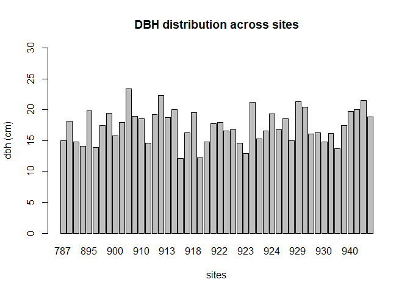

```r
barplot(scot_b$dbh, names.arg = scot_b$site,
        ylab = 'dbh (cm)',
        xlab = 'sites',
        main = 'DBH distribution across sites',
        ylim = c(0, 30))
```

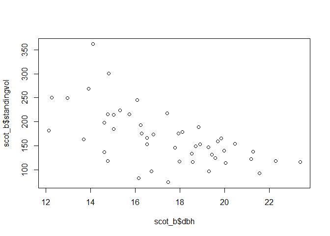

```r
plot(scot_b$dbh,scot_b$standingvol)
```

**Experimental design** A quick preview of the experimental design

```r
table(scot_a$site, scot_a$treatment)
```

```
##
##       A B F I
##   787 1 1 1 1
##   895 1 1 1 1
##   900 1 1 1 1
##   910 1 1 1 1
##   913 1 1 1 1
##   918 1 1 1 1
##   922 1 1 1 1
##   923 1 1 1 1
##   924 1 1 1 1
##   929 1 1 1 1
##   930 1 1 1 1
##   940 1 1 1 1
```

```r
table(scot_b$site, scot_b$treatment)
```

```
##
##       A C D I
##   787 1 1 1 1
##   895 1 1 1 1
##   900 1 1 1 1
##   910 1 1 1 1
##   913 1 1 1 1
##   918 1 1 1 1
##   922 1 1 1 1
##   923 1 1 1 1
##   924 1 1 1 1
##   929 1 1 1 1
##   930 1 1 1 1
##   940 1 1 1 1
```

The design is a randomized blocked design

### Total Volume Produced

```r
scot_a$tot_vol <- scot_a$standingvol + scot_a$harvestvol + scot_a$mortvol
```

```r
scot_b$tot_vol <- scot_b$standingvol + scot_b$harvestvol + scot_b$mortvol
```

**Volume produced by each treatments**

```r
summaryBy(tot_vol~treatment, data = scot_a, FUN = sum)
```

```
##   treatment tot_vol.sum
## 1         A    2757.481
## 2         B    2593.389
## 3         F    2607.507
## 4         I    2734.862
```

[output not shown]

```r
summaryBy(tot_vol~treatment, data = scot_b, FUN = sum)
```

```
##   treatment tot_vol.sum
## 1         A    2757.481
## 2         C    2427.520
## 3         D    2628.397
## 4         I    2734.862
```

[output not shown]

**Visualizing similar result**

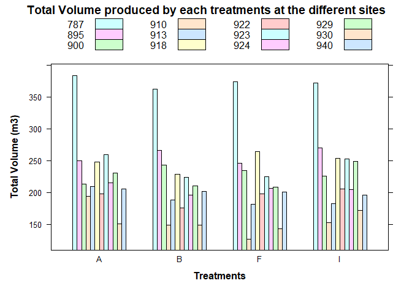

```r
barchart(tot_vol~treatment,
         data = scot_a,
         group = site,
         ylab = substitute(paste(bold('Total Volume (m3)'))),
         xlab = substitute(paste(bold('Treatments'))),
         main = 'Total Volume produced by each treatments at the different sites',
         auto.key = list(column = 4))
```

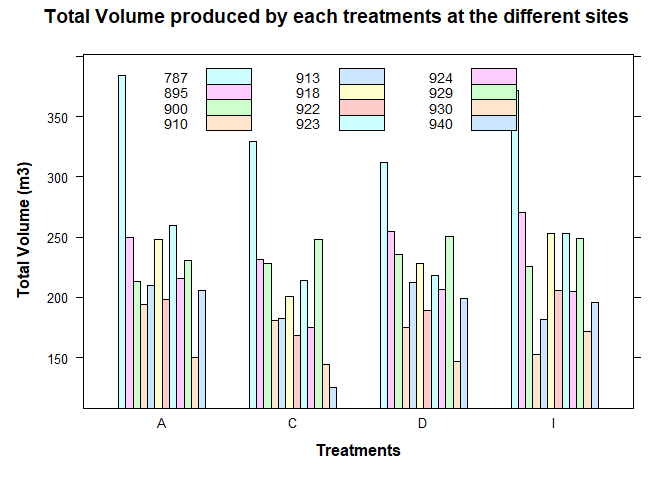

```r
barchart(tot_vol~treatment,
         data = scot_b,
         group = site,
         ylab = substitute(paste(bold('Total Volume (m3)'))),
         xlab = substitute(paste(bold('Treatments'))),
         main = 'Total Volume produced by each treatments at the different sites',
         auto.key = list(corner = c(0.4, 0.95), columns = 3, cex = 0.9),
         box.ratio = 2,)
```

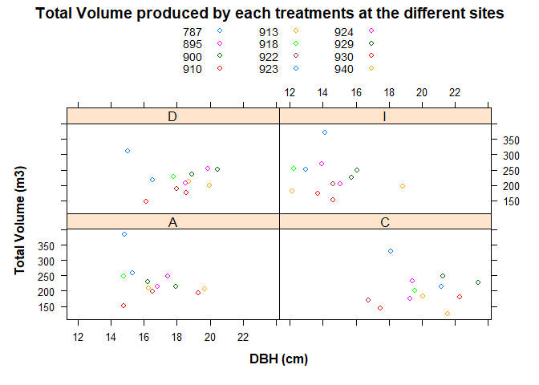

```r
xyplot(tot_vol~dbh | treatment,
         data = scot_b,
         group = site,
         ylab = substitute(paste(bold('Total Volume (m3)'))),
         xlab = substitute(paste(bold('DBH (cm)'))),
         main = 'Total Volume produced by each treatments at the different sites',
         auto.key = list(columns = 3, cex = 0.9))
```

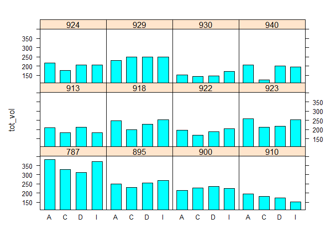

```r
barchart(tot_vol~treatment|site, data = scot_b)
```

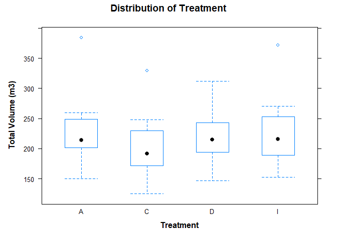

```r
bwplot(tot_vol~treatment, data = scot_b,
       xlab = substitute(paste(bold('Treatment'))),
       ylab = substitute(paste(bold('Total Volume (m3)'))),
       main = 'Distribution of Treatment')
```

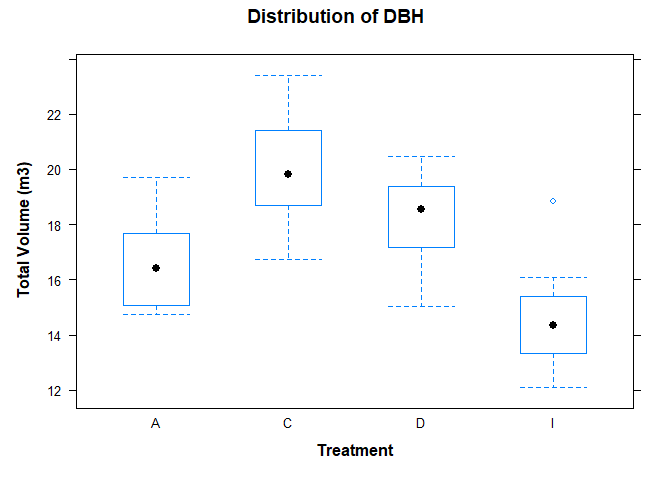

```r
bwplot(dbh~treatment, data = scot_b,
       xlab = substitute(paste(bold('Treatment'))),
       ylab = substitute(paste(bold('Total Volume (m3)'))),
       main = 'Distribution of DBH')
```

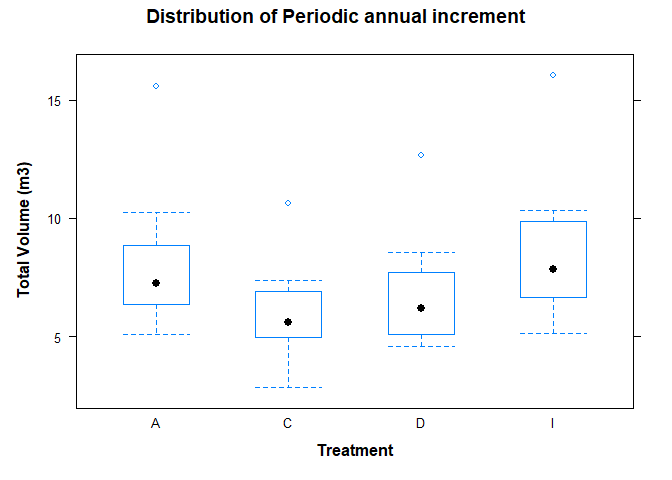

```r
bwplot(paiha~treatment, data = scot_b,
       xlab = substitute(paste(bold('Treatment'))),
       ylab = substitute(paste(bold('Total Volume (m3)'))),
       main = 'Distribution of Periodic annual increment')
```

```r
summaryBy(tot_vol + paiha + dbh ~ treatment,
          FUM = mean,
          data = scot_a)
```

```
##   treatment tot_vol.mean paiha.mean dbh.mean
## 1         A     229.7901   8.045398 16.65431
## 2         B     216.1158   7.067756 17.51680
## 3         F     217.2922   7.605466 13.91031
## 4         I     227.9052   8.489020 14.49433
```

```r
summaryBy(tot_vol + paiha + dbh ~ treatment,
          FUM = mean,
          data = scot_b)
```

```
##   treatment tot_vol.mean paiha.mean dbh.mean
## 1         A     229.7901   8.045398 16.65431
## 2         C     202.2933   5.970695 20.03243
## 3         D     219.0331   6.742520 18.21101
## 4         I     227.9052   8.489020 14.49433
```

### Analysis of Variance (ANOVA)

```r
## pai
sa_paiha <- lm(paiha ~ site+treatment , data = scot_a)

##tot_vol
sa_tvol <- lm(tot_vol ~ site+treatment , data = scot_a)

##tot_dbh
sa_dbh <- lm(dbh~site+treatment, data = scot_a)
```

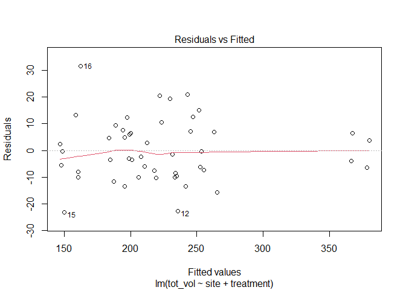

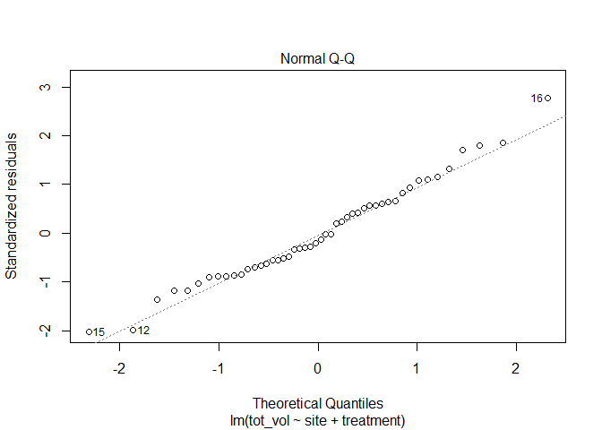

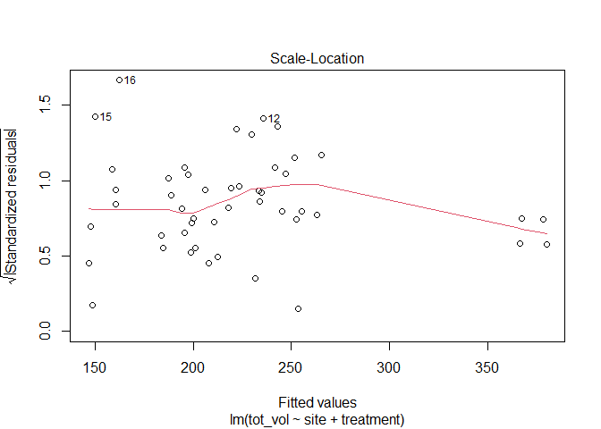

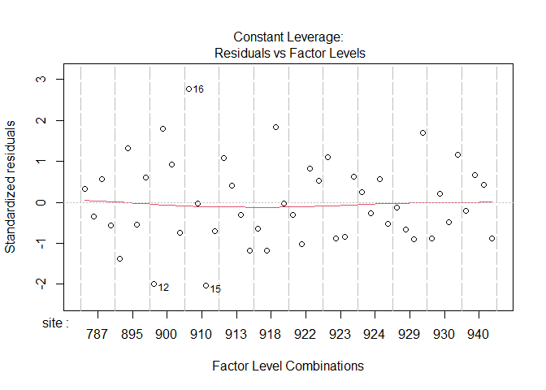

```r
plot(sa_tvol)
```

```r
## pai
sb_paiha <- lm(paiha ~ site+treatment , data = scot_b)
```

```r
##tot_vol
sb_tvol <- lm(tot_vol ~ site+treatment , data = scot_b)

##tot_dbh
sb_dbh <- lm(dbh~site+treatment, data = scot_b)
```

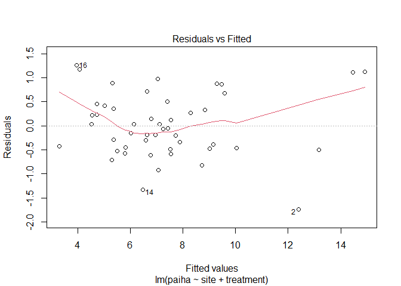

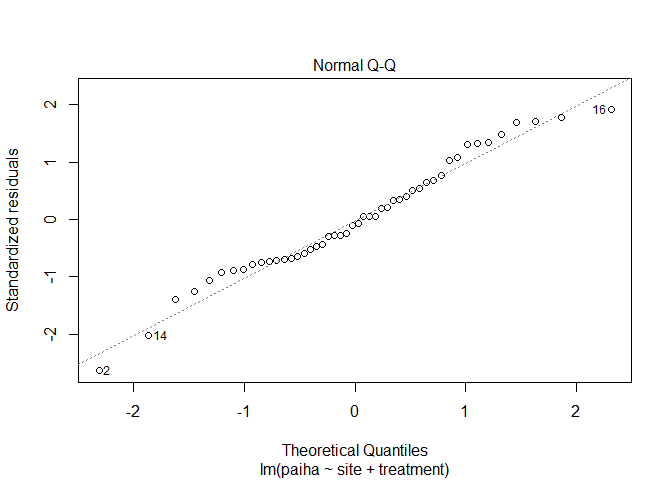

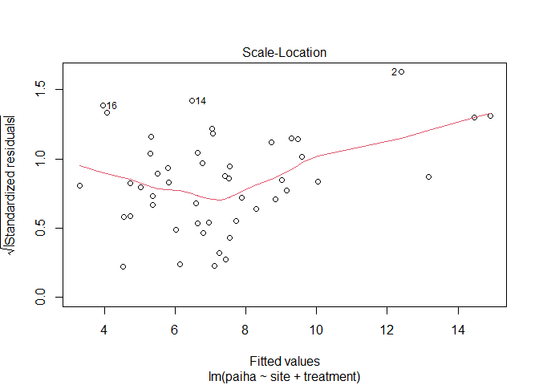

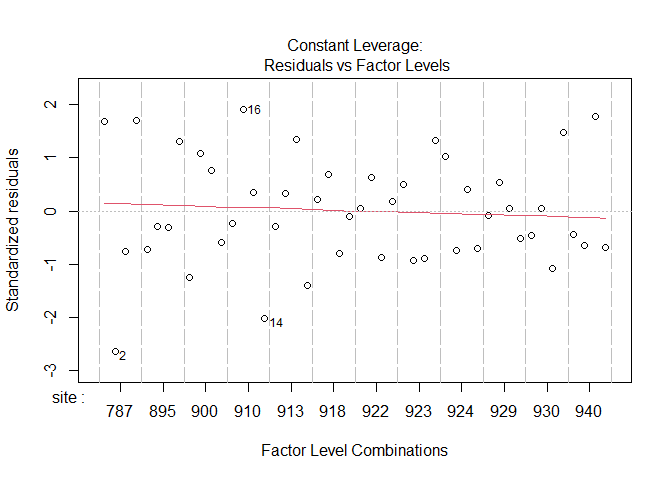

```r
plot(sb_paiha)
```

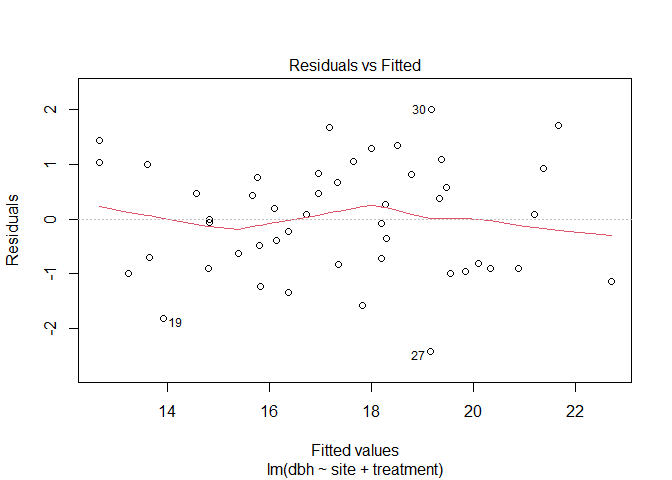

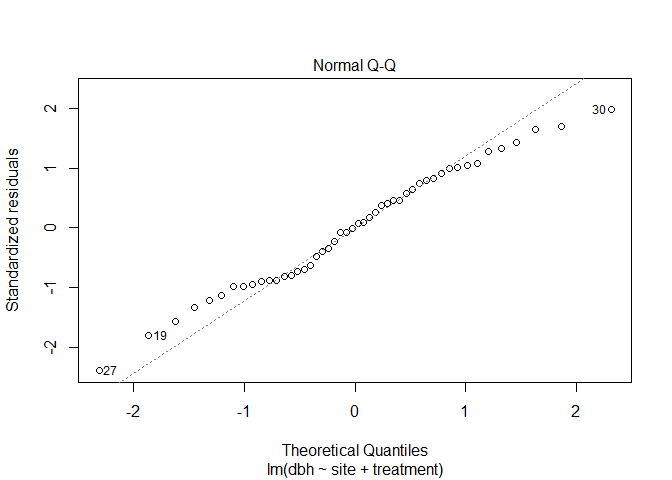

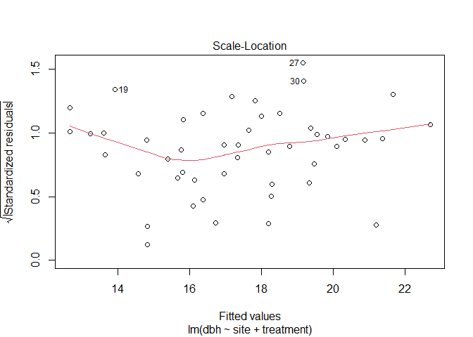

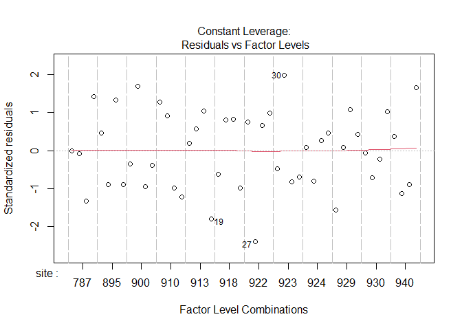

```r
plot(sb_dbh)
```

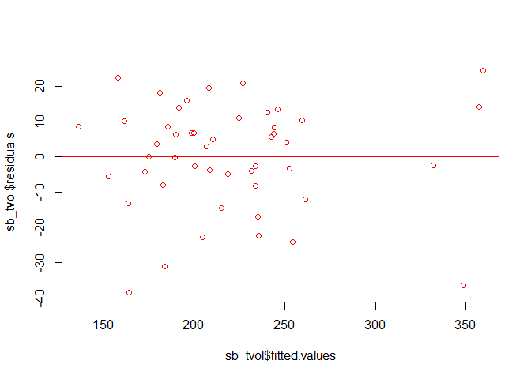

```r
plot(sb_tvol$fitted.values, sb_tvol$residuals,
     col = 'red')

abline(c(0,0), col='red')
```

```r
## tot_vol
anova(sa_tvol)
```

```
## Analysis of Variance Table
##
## Response: tot_vol
##           Df Sum Sq Mean Sq F value  Pr(>F)
## site      11 147104 13373.1 70.7531 < 2e-16 ***
## treatment  3   1799   599.7  3.1731 0.03696 *
## Residuals 33   6237   189.0
## ---
## Signif. codes:  0 '***' 0.001 '**' 0.01 '*' 0.05 '.' 0.1 ' ' 1
```

```r
##dbh
anova(sa_dbh)
```

```
## Analysis of Variance Table
##
## Response: dbh
##           Df  Sum Sq Mean Sq F value    Pr(>F)
## site      11 115.263  10.478  10.657 5.534e-08 ***
## treatment  3 106.266  35.422  36.027 1.607e-10 ***
## Residuals 33  32.446   0.983
## ---
## Signif. codes:  0 '***' 0.001 '**' 0.01 '*' 0.05 '.' 0.1 ' ' 1
```

```r
##pai
anova(sa_paiha)
```

```
## Analysis of Variance Table
##
## Response: paiha
##           Df Sum Sq Mean Sq F value    Pr(>F)
## site      11 360.62  32.784 61.9563 < 2.2e-16 ***
## treatment  3  13.31   4.436  8.3833 0.0002785 ***
## Residuals 33  17.46   0.529
## ---
## Signif. codes:  0 '***' 0.001 '**' 0.01 '*' 0.05 '.' 0.1 ' ' 1
```

In this analysis the effect of treatment and not block is the interest. There is a significant effect of treatment on total volume, dbh and periodic and annual increment.

```r
## tot_vol
anova(sb_tvol)
```

```
## Analysis of Variance Table
##
## Response: tot_vol
##           Df Sum Sq Mean Sq F value    Pr(>F)
## site      11 113743 10340.2 32.2852 1.702e-14 ***
## treatment  3   5671  1890.2  5.9019  0.002432 **
## Residuals 33  10569   320.3
## ---
## Signif. codes:  0 '***' 0.001 '**' 0.01 '*' 0.05 '.' 0.1 ' ' 1
```

```r
##dbh
anova(sb_dbh)
```

```
## Analysis of Variance Table
##
## Response: dbh
##           Df  Sum Sq Mean Sq F value    Pr(>F)
## site      11  92.933   8.448  5.6924 4.644e-05 ***
## treatment  3 198.907  66.302 44.6733 1.014e-11 ***
## Residuals 33  48.977   1.484
## ---
## Signif. codes:  0 '***' 0.001 '**' 0.01 '*' 0.05 '.' 0.1 ' ' 1
```

```r
##pai
anova(sb_paiha)
```

```
## Analysis of Variance Table
##
## Response: paiha
##           Df  Sum Sq Mean Sq F value    Pr(>F)
## site      11 255.696 23.2451  36.910 2.332e-15 ***
## treatment  3  48.560 16.1866  25.703 9.209e-09 ***
## Residuals 33  20.782  0.6298
## ---
## Signif. codes:  0 '***' 0.001 '**' 0.01 '*' 0.05 '.' 0.1 ' ' 1
```

In this analysis the effect of treatment and not block is the interest. There is a significant effect of treatment on total volume, dbh and periodic and annual increment.

### Post hoc test

**Total Volume**

```r
## Post hoc test
summary(TukeyC(sa_tvol, which = 'treatment'))
```

```
## Goups of means at sig.level = 0.05
##    Means G1
## A 229.79  a
## I 227.91  a
## F 217.29  a
## B 216.12  a
##
## Matrix of the difference of means above diagonal and
## respective p-values of the Tukey test below diagonal values
##       A     I      F      B
## A 0.000 1.885 12.498 13.674
## I 0.987 0.000 10.613 11.789
## F 0.137 0.251  0.000  1.176
## B 0.090 0.174  0.997  0.000
```

Post hoc test shows no difference in the effect of treatment on volume production

```r
## Post hoc test
summary(TukeyC(sb_tvol, which = 'treatment'))
```

```
## Goups of means at sig.level = 0.05
##    Means G1 G2
## A 229.79  a
## I 227.91  a
## D 219.03  a  b
## C 202.29     b
##
## Matrix of the difference of means above diagonal and
## respective p-values of the Tukey test below diagonal values
##       A     I      D      C
## A 0.000 1.885 10.757 27.497
## I 0.994 0.000  8.872 25.612
## D 0.465 0.622  0.000 16.740
## C 0.003 0.007  0.121  0.000
```

There is a difference in the effect of the treatment on total volume here. Here treatment A, and I are having similar effect on volume, producing almost similar volumes, while treatment D is having more or less similar effect on total volume produced as treatments A, I and C **Periodic Annual Increment Per hectare**

```r
## Post hoc test
summary(TukeyC(sa_paiha, which = 'treatment'))
```

```
## Goups of means at sig.level = 0.05
##   Means G1 G2 G3
## I  8.49  a
## A  8.05  a  b
## F  7.61     b  c
## B  7.07        c
##
## Matrix of the difference of means above diagonal and
## respective p-values of the Tukey test below diagonal values
##       I     A     F     B
## I 0.000 0.444 0.884 1.421
## A 0.453 0.000 0.440 0.978
## F 0.027 0.460 0.000 0.538
## B 0.000 0.012 0.287 0.000
```

Treatment I shows the highest in the periodic annual increment

```r
## Post hoc test
summary(TukeyC(sb_paiha, which = 'treatment'))
```

```
## Goups of means at sig.level = 0.05
##   Means G1 G2
## I  8.49  a
## A  8.05  a
## D  6.74     b
## C  5.97     b
##
## Matrix of the difference of means above diagonal and
## respective p-values of the Tukey test below diagonal values
##       I     A     D     C
## I 0.000 0.444 1.746 2.518
## A 0.527 0.000 1.303 2.075
## D 0.000 0.002 0.000 0.772
## C 0.000 0.000 0.100 0.000
```

**Diameter at breast height**

```r
## Post hoc test
summary(TukeyC(sa_dbh, which = 'treatment'))
```

```
## Goups of means at sig.level = 0.05
##   Means G1 G2
## B 17.52  a
## A 16.65  a
## I 14.49     b
## F 13.91     b
##
## Matrix of the difference of means above diagonal and
## respective p-values of the Tukey test below diagonal values
##       B     A     I     F
## B 0.000 0.862 3.022 3.606
## A 0.165 0.000 2.160 2.744
## I 0.000 0.000 0.000 0.584
## F 0.000 0.000 0.483 0.000
```

## Post hoc test

```r
T_dbh <- summary(TukeyC(sb_dbh, which = 'treatment'))
```

[output not shown]

Spacing Experiment

Homepage

Mixed Forest Experiment

[Back to portfolio](https://olamideadu.com)